# ggplot Choropleth Tutorial

# 1 How to make a ggplot Choropleth

While other tools (like [choroplethr](https://cran.r-project.org/web/packages/choroplethr/index.html)) can be used to make simple choropleth maps quickly, customization can be very difficult, and more importantly, require you to learn new skills. The ggplot2 package has choropleth functionality and data built right into it, using a few pre-defined tables of data accessed from the map_data(…) function, and plotted as a geom_polygon().

## 1.1 Example State Choropleth

To access state-level data, **carefully** join your table to the table returned by map_data(“state”), then plot the resulting polygons by latitude and longitude, using your data as the fill color. No additional steps are required (but the map will look kinda ugly).

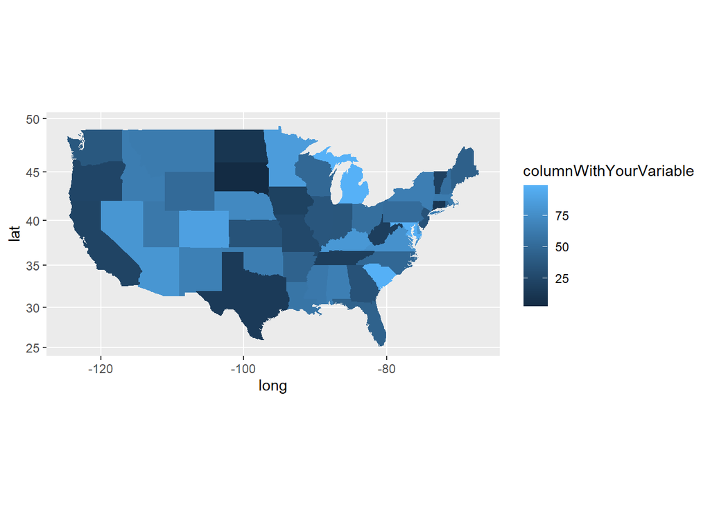

**Figure 1:** A Basic State Choropleth

```r
# Libraries

library(ggplot2)
library(tidyverse)
library(dplyr)

# Fake Data

#  Creating a tibble full of fake data
map_data("state") %>%
  # Giving it a state column
  select(columnWithStateNames = region) %>%
  # Eliminates spares
  distinct() %>%
  # Helps with random number generator
  rowwise() %>%
  # Filling it with fake data randomly assigned from 0 - 100
  mutate(columnWithYourVariable = runif(1, 0.0, 100.0)) %>%
  # Saving it as a csv
  write_csv("./output/yourTibbleData.csv")

# Joining Fake Data to Map Data

# Load in your data
choroplethData <- read_csv("./output/yourTibbleData.csv") %>%
  transmute(region = tolower(columnWithStateNames),
            # Get rid of everything except the state/country/county and the variable to use for your map
            columnWithYourVariable) %>%
  # This combines your data with the data from ggplot, keeping only things where the region name is an exact match
  # which is why the region name had to be converted to lowercase with tolower()
  right_join(map_data("state"), by = "region")
# The map data contains information on the shape of states/countries/counties and their latitude and longitude
# It uses these to create a bunch of polygons
# NOTE: Alaska and Hawaii are NOT included, but the District of Columbia is, due to geography

# Plotting the new combined data

# Your table with the shape data and the values of interest
ggplot(choroplethData,
           # Latitude
       aes(x = long,
           # Longitude
           y = lat,
           # Colors by the value of the variable
           fill = columnWithYourVariable,
           # Used for making the states/countries/counties
           group = group)) +
  # Used to draw the shapes
  geom_polygon() +
  # Fixes the aspect ratio
  coord_map() +
  # Saves your map
  ggsave("./figures/fakeStateChoropleth.png")
```

## 1.2 Example Country Choropleth

To make a country choropleth, provide “world” to the map_data(…) function. Using ggplot themes and other layers can make the plot look far less ugly.

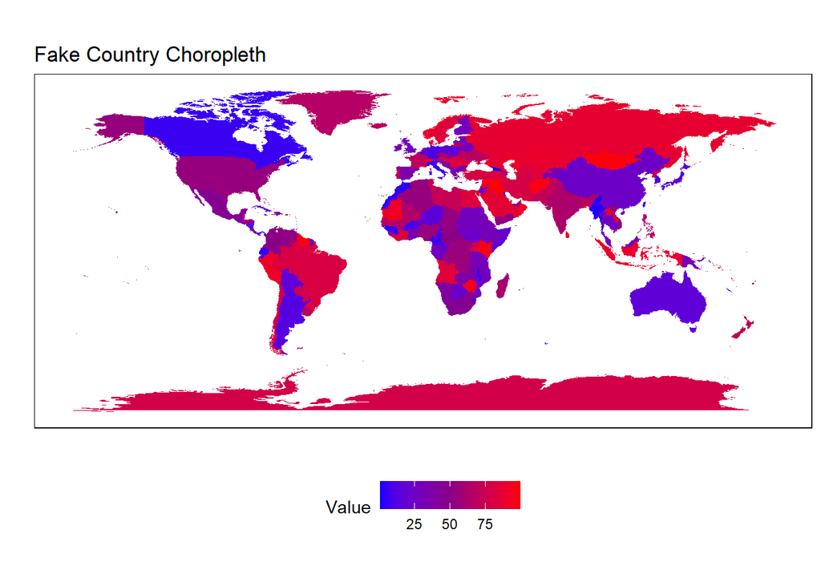

**Figure 2:** A Better Country Choropleth

```r
# Fake Data

map_data("world") %>%
  select(columnWithCountryNames = region) %>%
  distinct() %>%
  rowwise() %>%
  mutate(columnWithYourVariable = runif(1, 0.0, 100.0)) %>%
  write_csv("./output/yourTibbleData2.csv")

# Joining Fake Data to Map Data

choroplethData2 <- read_csv("./output/yourTibbleData2.csv") %>%
  # Country Names are NOT lowercase
  transmute(region = columnWithCountryNames,
            columnWithYourVariable) %>%
  right_join(map_data("world"), by = "region")

# Plotting the new combined data

ggplot(choroplethData2,
       aes(x = long,
           y = lat,
           fill = columnWithYourVariable,
           group = group)) +
  geom_polygon() +
  # Bad things happen if you try to use the coord_map() function here
  coord_quickmap() +
  # Additional themes and layers for reference
  scale_fill_gradient2(name = "Value",
                      low = "blue",
                      mid = "#880088",
                      midpoint = 50.0,
                      high = "red",
                      na.value = "black") +
  theme_linedraw() +
  theme(axis.text.x = element_blank(),
        axis.text.y = element_blank(),
        axis.ticks = element_blank(),
        panel.grid= element_blank(),
        legend.position = "bottom") +
  xlab("") +
  ylab("") +
  labs(title = "Fake Country Choropleth") +
  ggsave("./figures/fakeCountryChoropleth.png")
```

## 1.3 Example County Choropleth

Using the “county” map, and this time matching by subregion, allows for a very detailed look at the US. More advanced use of theme layers can result in something that’s actually worth keeping.

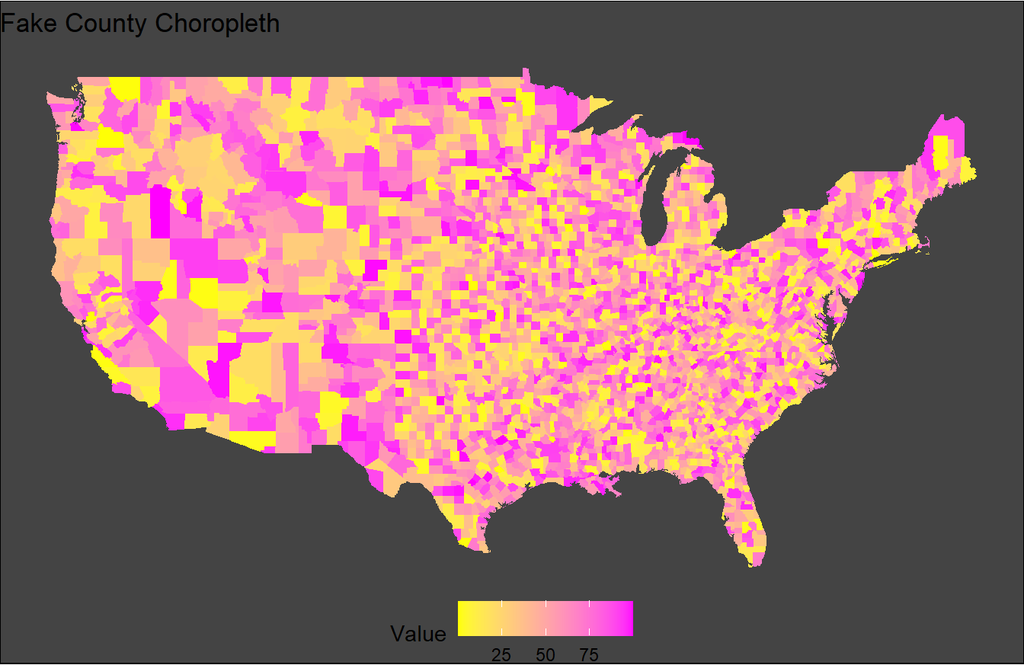

**Figure 3:** A Much Better County Choropleth

```r
# Fake Data

map_data("county") %>%
  select(columnWithCountyNames = subregion) %>%
  distinct() %>%
  rowwise() %>%
  mutate(columnWithYourVariable = runif(1, 0.0, 100.0)) %>%
  write_csv("./output/yourTibbleData3.csv")

# Joining Fake Data to Map Data

choroplethData3 <- read_csv("./output/yourTibbleData3.csv") %>%
  # County Names ARE lowercase, and are called "subregion"
  transmute(subregion = tolower(columnWithCountyNames),
            columnWithYourVariable) %>%
  # "subregion" in join
  right_join(map_data("county"), by = "subregion")

# Plotting the new combined data

ggplot(choroplethData3,
       aes(x = long,
           y = lat,
           fill = columnWithYourVariable,
           group = group)) +
  geom_polygon() +
  coord_map() +
  # Additional themes and layers for reference
  scale_fill_gradient(name = "Value",
                      low = "yellow",
                      high = "magenta",
                      na.value = "black") +
  theme_void() +
  theme(plot.background = element_rect(fill = "#444444"),
        plot.margin = unit(c(0, 0, 0, 0), "mm"),
        axis.text.x = element_blank(),
        axis.text.y = element_blank(),
        axis.ticks = element_blank(),
        panel.grid= element_blank(),
        legend.position = "bottom") +
  xlab("") +
  ylab("") +
  labs(title = "Fake County Choropleth") +
  # Aspect Ratio of ~ 15.28:9 when using coord_map on the continental US
  # The exact numbers are unimportant
  # A different aspect ratio will give whitespace in the saved image
  ggsave("./figures/fakeCountyChoropleth.png", width = 15.28, height = 9)
```